# Examining the Relationship between Age and Perceptions of Crime Safety

POL 501

```r
## Setting Up the Directory (REPLACE WITH YOUR FOLDER)
# Make sure to replace the directory path with the folder on your computer where the data file is stored.
setwd(r"(F:\Dropbox\PhD SBU\06_Teaching\00_POL-501\R Tutorials\SLR)")

## Confirm the working directory
# It's always good practice to confirm the working directory to avoid file path errors.
getwd()
```

```
## [1] "F:/Dropbox/PhD SBU/06_Teaching/00_POL-501/R Tutorials/SLR"
```

```r
# Load the SPSS data file
# Replace 'your_dataset.sav' with the path to your actual .sav file
pew_data <- read_sav("NPORS_2024_for_public_release.sav")

# Save the dataset as an R data file for easier reloading in the future.
saveRDS(pew_data, 'dataframe-pew.RData')

# Inspect column (variables) names to understand what data is available.
colnames(pew_data)
```

```
##  [1] "RESPID"            "MODE"              "LANGUAGE"
##  [4] "LANGUAGEINITIAL"   "LANG_PREF"         "SURVEYSTARTDATE"
##  [7] "SURVEYENDDATE"     "BWAVE"             "BIDENT1_GEOSTRATA"
## [10] "ECON1MOD"          "ECON1BMOD"         "COMTYPE2"
## [13] "UNITY"             "CRIMESAFE"         "INFRASPEND"
## [16] "MOREGUNIMPACT"     "GAMBLERESTR"       "VET1"
## [19] "VOL12_CPS"         "EMINUSE"           "INTMOB"
## [22] "INTFREQ"           "INTFREQ_COLLAPSED" "RADIO"
## [25] "DEVICE1A"          "SMART2"            "NHISLL"
## [28] "RELIGCAT1"         "REGISTRATION"      "PARTY"
## [31] "PARTYLN"           "PARTYSUM"          "HISP"
## [34] "RACEMOD_1"         "RACEMOD_2"         "RACEMOD_3"
## [37] "RACEMOD_4"         "RACEMOD_5"         "RACEMOD_6"
## [40] "RACEMOD_99"        "RACEMOD_MIXEDOE"   "RACECMB"
## [43] "RACETHN"           "AGE"               "AGECAT"
## [46] "BIRTHPLACE"        "GENDER"            "MARITAL"
## [49] "EDUCATION"         "EDUCCAT"           "ADULTS"
## [52] "VOTED2020"         "VOTEGEN_POST"      "INC_SDT1"
## [55] "CREGION"           "DIVISION"          "METRO"
## [58] "BASEWT"            "WEIGHT"
```

## Problem Description

In this analysis, we aim to investigate the relationship between age (as an independent variable) and perceptions of crime safety (as a dependent variable). The central question is whether age influences individuals’ perceptions of crime safety.

### Hypothesis

- **Independent Variable (IV):** Age (`AGE`)
- **Dependent Variable (DV):** Perception of crime safety (`CRIMESAFE`)

The hypothesis to test is whether there exists a significant linear relationship between age and perceptions of safety.

## Variables

- **`CRIMESAFE`**: Perception of safety in the respondent’s area concerning crime:
  - 1: Extremely safe
  - 2: Very safe
  - 3: Somewhat safe
  - 4: Not too safe
  - 5: Not at all safe
- **`PARTY`**: Political affiliation of the respondent with the following categories:
  - 1: Republican
  - 2: Democrat
  - 3: Independent
  - 4: Something else
- **`INTFREQ`**: About how often do you use the internet?

  – 1 = Almost constantly – 2 = Several times a day – 3 = About once a day – 4 = Several times a week – 5 = Less often

## Data Preparation and Variable Creation

We start by creating dummy variables for political affiliation, frequent internet users, and defining age cohorts. We are also creating additional variables, such as `Frequent_Internet_User`, which we do not directly use in the analysis. This is because we want to understand other potential factors that could explain variations in crime perception or other social behaviors, even if we do not analyze these factors right away. Additionally, creating more variables can help when expanding the analysis in the future.

```r
# Convert `PARTY` to factor to allow usage in dplyr operations
pew_data <- pew_data %>%
  mutate(
    PARTY = as_factor(PARTY),  # Convert PARTY to factor for easier interpretation

    # Create dummy variables for Democrats and Republicans
    Democrat = ifelse(PARTY == "Democrat", 1, 0),
    Republican = ifelse(PARTY == "Republican", 1, 0),

    # Define Frequent Internet User: `INTFREQ` values 1 and 2 represent frequent usage
    Frequent_Internet_User = ifelse(INTFREQ %in% c(1, 2), 1, 0),

    # Define Age Cohorts for more meaningful analysis of age differences
    Age_Cohort = case_when(
      AGE >= 18 & AGE <= 29 ~ "18-29 \n(Young Adults)",
      AGE >= 30 & AGE <= 39 ~ "30-39 \n(Early Middle Age)",
      AGE >= 40 & AGE <= 49 ~ "40-49 \n(Late Middle Age)",
      AGE >= 50 & AGE <= 64 ~ "50-64 \n(Pre-Retirement Age)",
      AGE >= 65 ~ "65+ \n(Seniors)",
      TRUE ~ "Unknown"  # Handles missing or unexpected age values
    ),

    # Handle non-valid values in CRIMESAFE (values above 97 are non-valid codes)
    CRIMESAFE = case_when(
      CRIMESAFE >= 97 ~ NA_real_,
      TRUE ~ CRIMESAFE
    ),

    # Create a dummy variable indicating if AGE is above the median age
    Age_Above_Median = ifelse(AGE > median(AGE, na.rm = TRUE), 1, 0)
)

# Check the distribution of respondents in each cohort
# This helps in understanding the sample size within each age category
table(pew_data$Age_Cohort)
```

```
##
##       18-29 \n(Young Adults)   30-39 \n(Early Middle Age)
##                          496                          768
##    40-49 \n(Late Middle Age) 50-64 \n(Pre-Retirement Age)
##                          829                         1482
##              65+ \n(Seniors)
##                         2051
```

```r
# Inspect distributions of key categorical variables
# Useful for understanding the balance of different groups in the dataset

# Distribution of political party affiliation
table(pew_data$PARTY)
```

```
##
##                   Republican                     Democrat
##                         1606                         1912
##                  Independent               Something else
##                         1403                          566
## Don't know/Refused/Web blank
##                          139
```

```r
# Count of Democrat dummy variable (0 = non-Democrat, 1 = Democrat)
table(pew_data$Democrat)
```

```
##
##    0    1
## 3714 1912
```

```r
# Count of Republican dummy variable (0 = non-Republican, 1 = Republican)
table(pew_data$Republican)
```

```
##
##    0    1
## 4020 1606
```

```r
# Count of frequent internet users (0 = Not frequent, 1 = Frequent)
table(pew_data$Frequent_Internet_User)
```

```
##
##    0    1
##  916 4710
```

```r
# Distribution of CRIMESAFE ratings (perceptions of crime safety)
table(pew_data$CRIMESAFE)
```

```
##
##    1    2    3    4    5
##  476 2106 2422  487  122
```

## Summary Statistics

We summarize key variables to understand their distributions.

```r
# Calculate summary statistics for selected variables using describe
# This provides measures like mean, standard deviation, min, and max for each variable
summary_stats <- pew_data %>%
  select(AGE, CRIMESAFE, Democrat, Republican, Frequent_Internet_User) %>%
  psych::describe()

# Display summary statistics in a nicely formatted table
kable(summary_stats, caption = "Summary Statistics for Key Variables")
```

Summary Statistics for Key Variables

|  | vars | n | mean | sd | median | trimmed | mad | min | max | range | skew | kurtosis | se |
| --- | --- | --- | --- | --- | --- | --- | --- | --- | --- | --- | --- | --- | --- |
| AGE | 1 | 5626 | 55.9857803 | 18.6020733 | 58 | 55.9737894 | 20.7564 | 18 | 99 | 81 | -0.0036579 | -0.6797732 | 0.2480056 |
| CRIMESAFE | 2 | 5613 | 2.5854267 | 0.8463885 | 3 | 2.5606769 | 1.4826 | 1 | 5 | 4 | 0.2788609 | 0.2713236 | 0.0112972 |
| Democrat | 3 | 5626 | 0.3398507 | 0.4737004 | 0 | 0.2998667 | 0.0000 | 0 | 1 | 1 | 0.6760426 | -1.5432406 | 0.0063154 |
| Republican | 4 | 5626 | 0.2854604 | 0.4516736 | 0 | 0.2318969 | 0.0000 | 0 | 1 | 1 | 0.9498077 | -1.0980605 | 0.0060218 |
| Frequent_Internet_User | 5 | 5626 | 0.8371845 | 0.3692301 | 1 | 0.9213683 | 0.0000 | 0 | 1 | 1 | -1.8260949 | 1.3348598 | 0.0049226 |

## Visualizing AGE and CRIMESAFE

To explore the data, we visualize the distribution of age and perceptions of safety (`CRIMESAFE`) using bar plots and box plots.

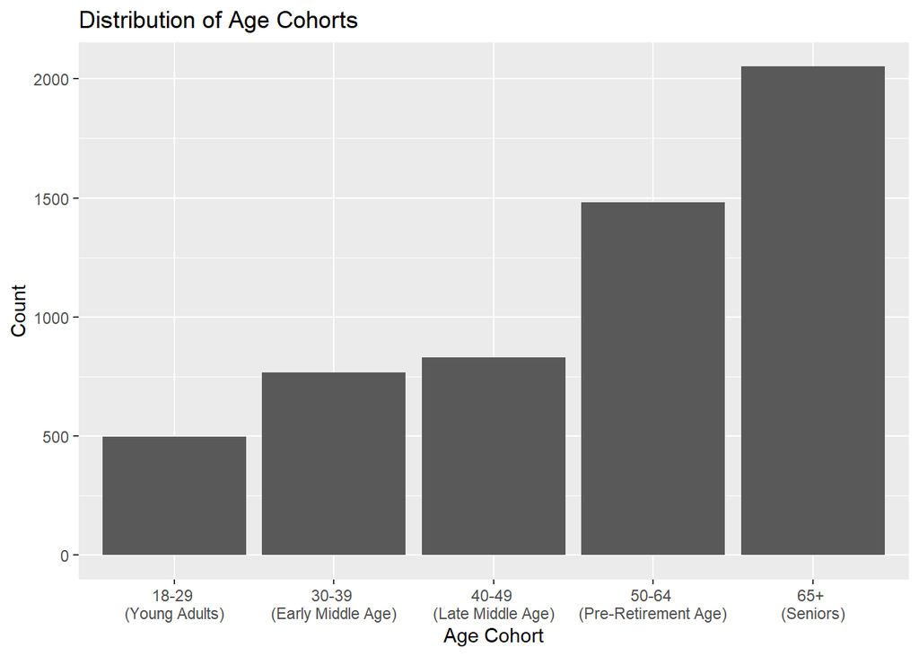

```r
# Bar plot for the distribution of age cohorts
# Helps us see the number of respondents in each age category

ggplot(pew_data, aes(x = as.factor(Age_Cohort))) +
  geom_bar() +
  labs(title = "Distribution of Age Cohorts", x = "Age Cohort", y = "Count")
```

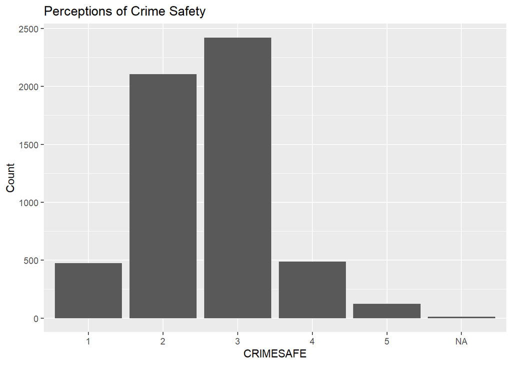

```r
# Bar plot for perceptions of crime safety
# Provides insight into how people rate safety in their area

ggplot(pew_data, aes(x = as.factor(CRIMESAFE))) +
  geom_bar() +
  labs(title = "Perceptions of Crime Safety", x = "CRIMESAFE", y = "Count")
```

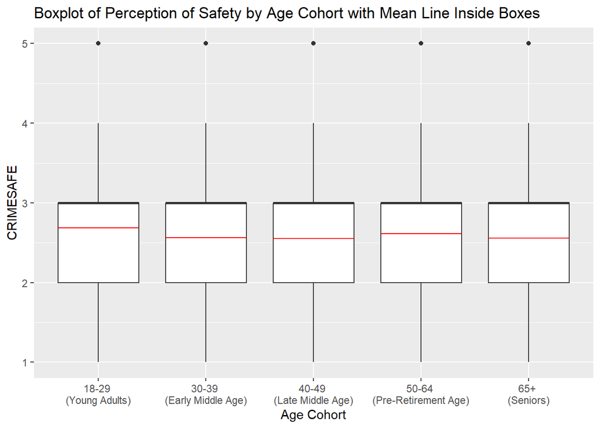

```r
# Box plot of CRIMESAFE by Age Cohort
# Shows differences in perception of crime safety across different age groups

# Box plot of CRIMESAFE by Age Cohort
# Filter out rows with missing CRIMESAFE values
ggplot(pew_data %>% filter(!is.na(CRIMESAFE)), aes(x = as.factor(Age_Cohort), y = CRIMESAFE)) +
  geom_boxplot() +
  stat_summary(fun = mean, geom = "crossbar", width = 0.75, color = "red", linewidth = 0.2) +  # Add mean line within the box
  labs(title = "Boxplot of Perception of Safety by Age Cohort with Mean Line Inside Boxes",
       x = "Age Cohort",
       y = "CRIMESAFE")
```

## Hypothesis Testing: T-test and Z-test

### T-tests

```r
# Perform independent sample t-tests to compare AGE and CRIMESAFE between Republicans and non-Republicans
# A t-test is useful here to determine if the mean difference between groups is statistically significant

t_test_age <- t.test(AGE ~ Republican, data = pew_data)
t_test_crimesafe <- t.test(CRIMESAFE ~ Republican, data = pew_data)

# Display t-test results
# Look at the p-values to determine statistical significance
print(t_test_age)
```

```
##
##  Welch Two Sample t-test
##
## data:  AGE by Republican
## t = -8.4195, df = 3121.8, p-value < 2.2e-16
## alternative hypothesis: true difference in means between group 0 and group 1 is not equal to 0
## 95 percent confidence interval:
##  -5.524166 -3.437245
## sample estimates:
## mean in group 0 mean in group 1
##        54.70672        59.18742
```

```r
print(t_test_crimesafe)
```

```
##
##  Welch Two Sample t-test
##
## data:  CRIMESAFE by Republican
## t = -0.75854, df = 3123.5, p-value = 0.4482
## alternative hypothesis: true difference in means between group 0 and group 1 is not equal to 0
## 95 percent confidence interval:
##  -0.06621993  0.02927564
## sample estimates:
## mean in group 0 mean in group 1
##        2.580155        2.598627
```

### Additional Hypothesis Test: Age Above Median

We also test whether individuals whose age is above the median have different perceptions of crime safety compared to those below or equal to the median. This helps in understanding whether older respondents, in general, have different safety perceptions.

```r
# Perform independent sample t-test to compare CRIMESAFE between respondents above and below the median age
# This test checks if older individuals perceive safety differently compared to younger individuals

t_test_crimesafe_age_median <- t.test(CRIMESAFE ~ Age_Above_Median, data = pew_data)

# Display t-test results
print(t_test_crimesafe_age_median)
```

```
##
##  Welch Two Sample t-test
##
## data:  CRIMESAFE by Age_Above_Median
## t = 1.4889, df = 5606.1, p-value = 0.1366
## alternative hypothesis: true difference in means between group 0 and group 1 is not equal to 0
## 95 percent confidence interval:
##  -0.01061952  0.07768745
## sample estimates:
## mean in group 0 mean in group 1
##        2.601581        2.568047
```

### Z-tests

In addition to the t-tests, we will also perform Z-tests for the differences in means. Z-tests are used when we assume that the population variances are known, or the sample sizes are large enough for the Central Limit Theorem to apply.

For the purpose of this analysis, we are estimating the population standard deviation from our sample and using that to perform Z-tests. Z-tests are often preferred when dealing with large sample sizes, as they tend to be more reliable under those conditions.

```r
# Enhanced Z-test function with group description in output
doz_test <- function(data, x_var, group_var) {
  # Separate data into two groups based on the group_var
  group1_data <- data[[x_var]][data[[group_var]] == 1]
  group2_data <- data[[x_var]][data[[group_var]] == 0]

  # Calculate mean, standard deviation, and sample size for each group
  mean1 <- mean(group1_data, na.rm = TRUE)
  mean2 <- mean(group2_data, na.rm = TRUE)
  sd1 <- sd(group1_data, na.rm = TRUE)
  sd2 <- sd(group2_data, na.rm = TRUE)
  n1 <- sum(!is.na(group1_data))
  n2 <- sum(!is.na(group2_data))

  # Calculate the standard error and Z-score
  se <- sqrt((sd1^2 / n1) + (sd2^2 / n2))
  z <- (mean1 - mean2) / se
  p_value <- 2 * (1 - pnorm(abs(z)))

  # Return a comprehensive list of all relevant values including group description
  list(
    group1_mean = mean1,
    group2_mean = mean2,
    group1_sd = sd1,
    group2_sd = sd2,
    group1_n = n1,
    group2_n = n2,
    standard_error = se,
    z_score = z,
    p_value = p_value,
    group_description = paste("Group is ID=1 if", group_var, "= 1")
  )
}

# Perform Z-test for AGE with 'AGE' as the variable of interest and 'Republican' as the grouping variable
print('Z-Test for Differences of Means for AGE, for Republicans (=1) and Non-Reps (=0)')
```

```
## [1] "Z-Test for Differences of Means for AGE, for Republicans (=1) and Non-Reps (=0)"
```

```r
doz_test(pew_data, x_var = "AGE", group_var = "Republican")
```

```
## $group1_mean
## [1] 59.18742
##
## $group2_mean
## [1] 54.70672
##
## $group1_sd
## [1] 17.71158
##
## $group2_sd
## [1] 18.7964
##
## $group1_n
## [1] 1606
##
## $group2_n
## [1] 4020
##
## $standard_error
## [1] 0.5321811
##
## $z_score
## [1] 8.419513
##
## $p_value
## [1] 0
##
## $group_description
## [1] "Group is ID=1 if Republican = 1"
```

```r
# Perform Z-test for CRIMESAFE with 'CRIMESAFE' as the variable of interest and 'Republican' as the grouping variable
cat("\n")
```

```r
print('Z-Test for Differences of Means for CRIMESAFE, for Republicans (=1) and Non-Reps (=0)')
```

```
## [1] "Z-Test for Differences of Means for CRIMESAFE, for Republicans (=1) and Non-Reps (=0)"
```

```r
doz_test(pew_data, x_var = "CRIMESAFE", group_var = "Republican")
```

```
## $group1_mean
## [1] 2.598627
##
## $group2_mean
## [1] 2.580155
##
## $group1_sd
## [1] 0.8086497
##
## $group2_sd
## [1] 0.861041
##
## $group1_n
## [1] 1602
##
## $group2_n
## [1] 4011
##
## $standard_error
## [1] 0.02435212
##
## $z_score
## [1] 0.7585434
##
## $p_value
## [1] 0.4481257
##
## $group_description
## [1] "Group is ID=1 if Republican = 1"
```

Note that we can also use functions from packages to run the Z test. The results should be the same as the computation “by-hand” we did when we defined the function above.

```r
# Install the BSDA package if not already installed
if (!require("BSDA")) install.packages("BSDA")
library(BSDA)
# Perform independent sample Z-tests to compare AGE and CRIMESAFE between Republicans and non-Republicans
# A Z-test from BSDA package is used here for large sample sizes

# Z-test for AGE between Republicans and non-Republicans
z_test_age <- z.test(x = pew_data$AGE[pew_data$Republican == 1],
                     y = pew_data$AGE[pew_data$Republican == 0],
                     sigma.x = sd(pew_data$AGE[pew_data$Republican == 1], na.rm = TRUE),
                     sigma.y = sd(pew_data$AGE[pew_data$Republican == 0], na.rm = TRUE))

# Print Z-test result for AGE
print(z_test_age)
```

```
##
##  Two-sample z-Test
##
## data:  pew_data$AGE[pew_data$Republican == 1] and pew_data$AGE[pew_data$Republican == 0]
## z = 8.4195, p-value < 2.2e-16
## alternative hypothesis: true difference in means is not equal to 0
## 95 percent confidence interval:
##  3.437650 5.523762
## sample estimates:
## mean of x mean of y
##  59.18742  54.70672
```

```r
# Z-test for CRIMESAFE between Republicans and non-Republicans
z_test_crimesafe <- z.test(x = pew_data$CRIMESAFE[pew_data$Republican == 1],
                           y = pew_data$CRIMESAFE[pew_data$Republican == 0],
                           sigma.x = sd(pew_data$CRIMESAFE[pew_data$Republican == 1], na.rm = TRUE),
                           sigma.y = sd(pew_data$CRIMESAFE[pew_data$Republican == 0], na.rm = TRUE))

# Print Z-test result for CRIMESAFE
print(z_test_crimesafe)
```

```
##
##  Two-sample z-Test
##
## data:  pew_data$CRIMESAFE[pew_data$Republican == 1] and pew_data$CRIMESAFE[pew_data$Republican == 0]
## z = 0.75854, p-value = 0.4481
## alternative hypothesis: true difference in means is not equal to 0
## 95 percent confidence interval:
##  -0.02925714  0.06620142
## sample estimates:
## mean of x mean of y
##  2.598627  2.580155
```

## Chi-Square Test for Age Cohorts and Perceptions of Crime Safety

We conduct a chi-square test to assess the association between age cohorts and perceptions of crime safety.

```r
# Create a contingency table between Age Cohort and CRIMESAFE
# Useful to understand if there is an association between these two categorical variables
age_crimesafe_table <- table(pew_data$Age_Cohort, pew_data$CRIMESAFE)

# Display the contingency table using kable for easy reading
kable(age_crimesafe_table, caption = "Contingency Table of Age Cohorts and Perceptions of Crime Safety")
```

Contingency Table of Age Cohorts and Perceptions of Crime Safety

|  | 1 | 2 | 3 | 4 | 5 |
| --- | --- | --- | --- | --- | --- |
| 18-29 |  |  |  |  |  |
| (Young Adults) | 43 | 154 | 223 | 64 | 11 |
| 30-39 |  |  |  |  |  |
| (Early Middle Age) | 85 | 280 | 309 | 70 | 23 |
| 40-49 |  |  |  |  |  |
| (Late Middle Age) | 80 | 322 | 336 | 69 | 21 |
| 50-64 |  |  |  |  |  |
| (Pre-Retirement Age) | 112 | 551 | 642 | 134 | 37 |
| 65+ |  |  |  |  |  |
| (Seniors) | 156 | 799 | 912 | 150 | 30 |

```r
# Perform chi-square test to assess the independence of age cohort and perceptions of safety
# A significant p-value indicates a possible relationship
chi_square_test <- chisq.test(age_crimesafe_table)

# Display the results
chi_square_test
```

```
##
##  Pearson's Chi-squared test
##
## data:  age_crimesafe_table
## X-squared = 45.659, df = 16, p-value = 0.0001099
```

## Scatter Plot between AGE and CRIMESAFE

We plot the relationship between `AGE` and `CRIMESAFE` to visualize any linear association.

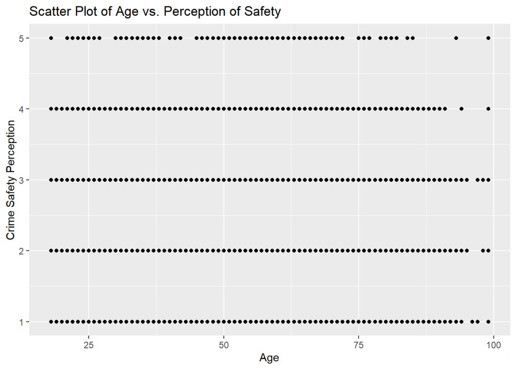

```r
# Scatter plot of AGE vs CRIMESAFE
# Useful to get a first visual impression of any linear relationship

# Scatter plot of AGE vs CRIMESAFE with missing values removed
ggplot(na.omit(pew_data[, c("AGE", "CRIMESAFE")]), aes(x = AGE, y = CRIMESAFE)) +
  geom_point() +
  labs(title = "Scatter Plot of Age vs. Perception of Safety", x = "Age", y = "Crime Safety Perception")
```

### Discussion

- The scatter plot is not very useful here because `CRIMESAFE` is an ordinal variable with a limited number of levels, which results in many overlapping points.
- Instead, it’s better to plot the mean `CRIMESAFE` by age cohort along with confidence intervals to get a clearer view of trends across age groups.

### Code to Plot Mean `CRIMESAFE` by Age Cohort with Confidence Intervals

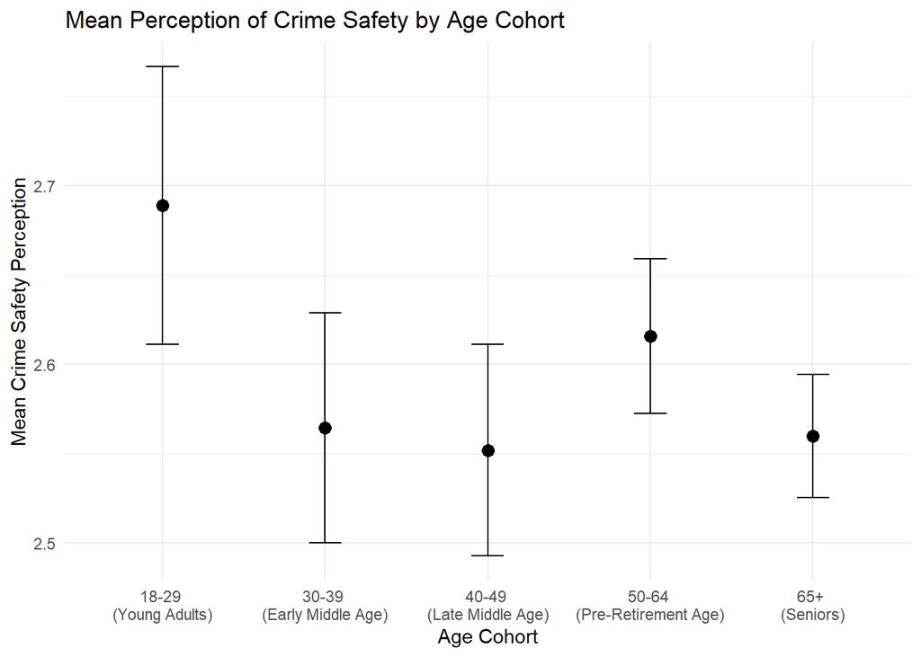

```r
# Calculate mean CRIMESAFE and confidence intervals by Age Cohort
summary_data <- pew_data %>%
  group_by(Age_Cohort) %>%
  summarise(
    mean_crimesafe = mean(CRIMESAFE, na.rm = TRUE),
    se_crimesafe = sd(CRIMESAFE, na.rm = TRUE) / sqrt(n())
  )

# Plot the mean CRIMESAFE by Age Cohort with confidence intervals
# This provides a more interpretable view of differences between age groups

ggplot(summary_data, aes(x = Age_Cohort, y = mean_crimesafe)) +
  geom_point(size = 3) +
  geom_errorbar(aes(ymin = mean_crimesafe - 1.96 * se_crimesafe,
                    ymax = mean_crimesafe + 1.96 * se_crimesafe), width = 0.2) +
  labs(title = "Mean Perception of Crime Safety by Age Cohort",
       x = "Age Cohort",
       y = "Mean Crime Safety Perception") +
  theme_minimal()
```

### Explanation

- **`mean_crimesafe`**: The average `CRIMESAFE` value per age cohort.
- **`se_crimesafe`**: The standard error of `CRIMESAFE`, used to calculate 95% confidence intervals.
- **`geom_errorbar()`**: Adds error bars for confidence intervals around the mean.

This plot will provide a clear view of how perceptions of safety vary by age cohort.

Note that the response scale for `CRIMESAFE` is such that higher numbers imply stronger perceptions of insecurity.

## Correlation Analysis

To further understand the relationship between `AGE` and `CRIMESAFE`, we calculate the Pearson correlation coefficient.

```r
# Calculate the Pearson correlation coefficient between AGE and CRIMESAFE
# This provides a summary measure of the strength and direction of the linear relationship
# Perform the correlation test for AGE and CRIMESAFE
cor_test_result <- cor.test(pew_data$AGE, pew_data$CRIMESAFE, use = "complete.obs")

# Display the correlation coefficient and p-value
print(paste("The Pearson correlation coefficient between AGE and CRIMESAFE is:", round(cor_test_result$estimate, 2)))
```

```
## [1] "The Pearson correlation coefficient between AGE and CRIMESAFE is: -0.02"
```

```r
print(paste("p-value:", round(cor_test_result$p.value, 4)))
```

```
## [1] "p-value: 0.0653"
```

### Discussion

- The Pearson correlation coefficient provides a value between -1 and 1. Values closer to 1 indicate a strong positive relationship, while values closer to -1 indicate a strong negative relationship. Values near 0 indicate a weak or no linear relationship.

## Simple Linear Regression

We fit a linear model using `lm` to estimate the relationship between `AGE` and `CRIMESAFE`.

```r
# Fit a linear model to predict CRIMESAFE based on AGE
# The goal is to see if there is a significant linear relationship between age and safety perception
lm_model <- lm(CRIMESAFE ~ AGE, data = pew_data)

# Display the regression output
# Look for the p-value and coefficients to understand if AGE significantly predicts CRIMESAFE
summary(lm_model)
```

```
##
## Call:
## lm(formula = CRIMESAFE ~ AGE, data = pew_data)
##
## Residuals:
##     Min      1Q  Median      3Q     Max
## -1.6279 -0.5865  0.3855  0.4269  2.4627
##
## Coefficients:
##               Estimate Std. Error t value Pr(>|t|)
## (Intercept)  2.6480729  0.0358097  73.948   <2e-16 ***
## AGE         -0.0011191  0.0006071  -1.844   0.0653 .
## ---
## Signif. codes:  0 '***' 0.001 '**' 0.01 '*' 0.05 '.' 0.1 ' ' 1
##
## Residual standard error: 0.8462 on 5611 degrees of freedom
##   (13 observations deleted due to missingness)
## Multiple R-squared:  0.0006053,  Adjusted R-squared:  0.0004272
## F-statistic: 3.399 on 1 and 5611 DF,  p-value: 0.06531
```

```r
kable(summary(lm_model)$coefficients, caption = "Regression Output for Linear Model")
```

Regression Output for Linear Model

|  | Estimate | Std. Error | t value | Pr(>\|t\|) |
| --- | --- | --- | --- | --- |
| (Intercept) | 2.6480729 | 0.0358097 | 73.948439 | 0.0000000 |
| AGE | -0.0011191 | 0.0006071 | -1.843521 | 0.0653057 |

## Analysis

The output provided is the summary of a simple linear regression model where `CRIMESAFE` (perception of crime safety) is the dependent variable, and `AGE` is the independent variable. Here’s a detailed breakdown of how to interpret each section of the output:

### Call

```r
## Call:
## lm(formula = CRIMESAFE ~ AGE, data = pew_data)
```

This indicates the model specification. It shows that we’re modeling `CRIMESAFE` as a function of `AGE` using data from `pew_data`.

### Residuals

```r
## Residuals:
##     Min      1Q  Median      3Q     Max
## -1.6279 -0.5865  0.3855  0.4269  2.4627
```

The residuals section provides a summary of the distribution of residuals (differences between observed and predicted values) for the model:

- **Min**: Minimum residual value, which is -1.6279.
- **1Q** (1st Quartile): 25th percentile of residuals, -0.5865.
- **Median**: Median residual value, 0.3855.
- **3Q** (3rd Quartile): 75th percentile of residuals, 0.4269.
- **Max**: Maximum residual value, 2.4627.

### Coefficients

```r
## Coefficients:
##               Estimate Std. Error t value Pr(>|t|)
## (Intercept)  2.6480729  0.0358097  73.948   <2e-16 ***
## AGE         -0.0011191  0.0006071  -1.844   0.0653 .
```

The **Coefficients** table presents details on the intercept and the effect of `AGE` on `CRIMESAFE`:

- **(Intercept)**:
  - **Estimate**: `2.6480729` is the predicted value of `CRIMESAFE` when `AGE` is zero.
  - **Std. Error**: `0.0358097` is the standard error for the intercept estimate, showing the uncertainty of this estimate.
  - **t value**: `73.948` is the t-statistic for testing whether the intercept differs significantly from zero.
  - **Pr(>|t|)**: `<2e-16` (a very small p-value) indicates that the intercept is statistically significant at conventional levels (p < 0.001).
- **AGE**:
  - **Estimate**: `-0.0011191` is the estimated coefficient for `AGE`, meaning that for each additional year of age, `CRIMESAFE` is expected to decrease by approximately 0.0011 units, holding other factors constant.
  - **Std. Error**: `0.0006071` is the standard error of this estimate, indicating the level of uncertainty in the estimate.
  - **t value**: `-1.844` is the t-statistic for testing whether the `AGE` coefficient is significantly different from zero.
  - **Pr(>|t|)**: `0.0653` is the p-value for the t-test. With a p-value of 0.0653, the effect of `AGE` on `CRIMESAFE` is marginally insignificant at the typical 5% significance level (p < 0.05), though it approaches significance at the 10% level (p < 0.1).

#### Significance Codes

- **Significance codes**: The symbols next to the p-values (e.g., `***`, `.`) indicate significance levels:
  - `***`: p < 0.001 (highly significant)
  - `*`: p < 0.05 (significant)
  - `.`: p < 0.1 (marginally significant)
  - No symbol indicates that the coefficient is not statistically significant.

Here, the intercept is highly significant, while the effect of `AGE` is marginally significant at the 10% level.

### Residual Standard Error

```r
## Residual standard error: 0.8462 on 5611 degrees of freedom
```

The **Residual Standard Error** of `0.8462` represents the average distance that observed values fall from the regression line. Lower values indicate a better fit. The **degrees of freedom** here is `5611`, calculated as the number of observations minus the number of estimated parameters.

### R-squared and Adjusted R-squared

```r
## Multiple R-squared:  0.0006053,  Adjusted R-squared:  0.0004272
```

- **Multiple R-squared**: `0.0006053` indicates that approximately 0.06% of the variability in `CRIMESAFE` is explained by `AGE`, suggesting a weak relationship.
- **Adjusted R-squared**: `0.0004272` adjusts the R-squared for the number of predictors in the model. Because this model has only one predictor, adjusted R-squared is almost the same as R-squared.

A very low R-squared implies that `AGE` does not strongly predict `CRIMESAFE`.

### F-statistic

```r
## F-statistic: 3.399 on 1 and 5611 DF,  p-value: 0.06531
```

- **F-statistic**: `3.399` tests the overall significance of the model.
- **p-value**: `0.06531` indicates that the model is not statistically significant at the 5% level (p < 0.05) but is marginally significant at the 10% level (p < 0.1).

### Summary

- The regression shows a weak, marginally significant negative association between `AGE` and `CRIMESAFE`.
- The model does not explain much variance in `CRIMESAFE`, as indicated by the very low R-squared.

## Scatter Plot with Regression Line

We add the regression line using the model coefficients to illustrate the fitted linear relationship.

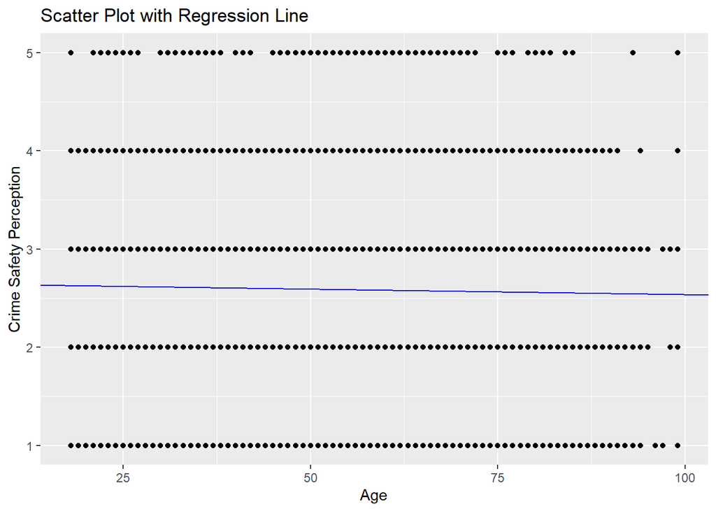

```r
# Extract coefficients for manual regression line
intercept <- coef(lm_model)[1]
slope <- coef(lm_model)[2]

# Scatter plot of AGE vs CRIMESAFE with regression line
# This visualization helps in understanding the overall trend modeled by the linear regression

ggplot(pew_data, aes(x = AGE, y = CRIMESAFE)) +
  geom_point() +
  geom_abline(intercept = intercept, slope = slope, color = "blue") +
  labs(title = "Scatter Plot with Regression Line", x = "Age", y = "Crime Safety Perception")
```

## Residual Analysis

Residual analysis is important to verify the assumptions of linear regression.

### Constant Variance of Residuals

We plot the residuals against `AGE` to check for constant variance (homoscedasticity).

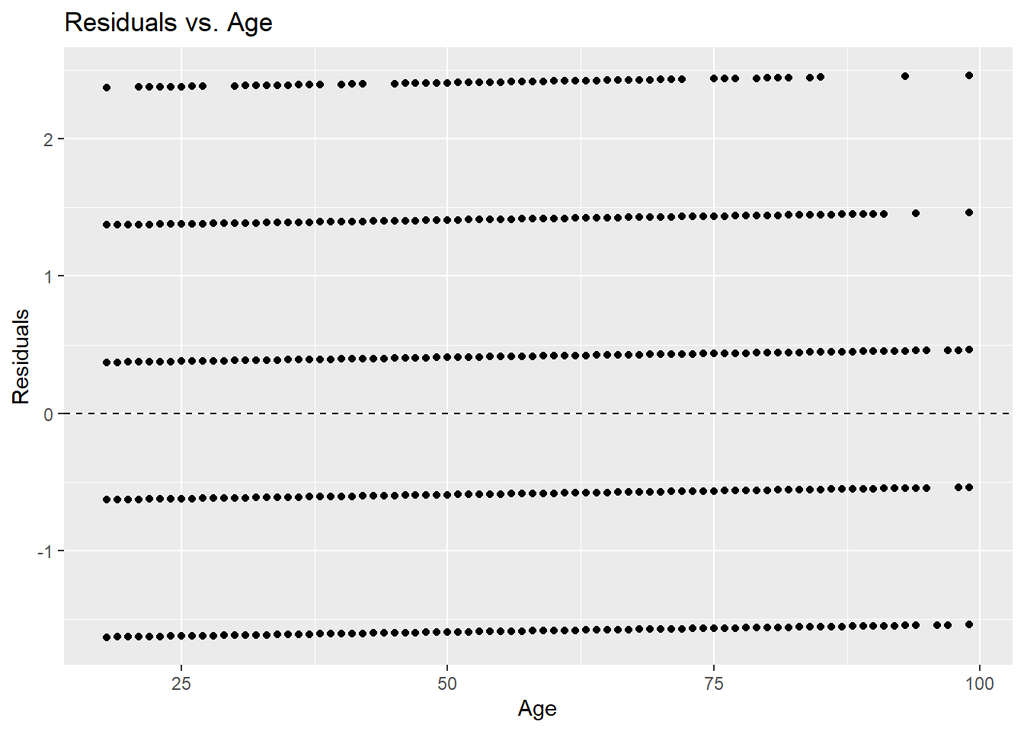

```r
# Extract data used in the lm_model to ensure matching row count
model_data <- model.frame(lm_model)

# Extract residuals from the model
residuals <- resid(lm_model)

# Plot residuals against AGE
# This helps us determine if there is any pattern in the residuals, indicating potential issues with the model

ggplot(data.frame(AGE = model_data$AGE, Residuals = residuals), aes(x = AGE, y = Residuals)) +
  geom_point() +
  geom_hline(yintercept = 0, linetype = "dashed") +
  labs(title = "Residuals vs. Age", x = "Age", y = "Residuals")
```

### Normality of Residuals

We examine the normality of residuals using a histogram with a superimposed normal density curve.

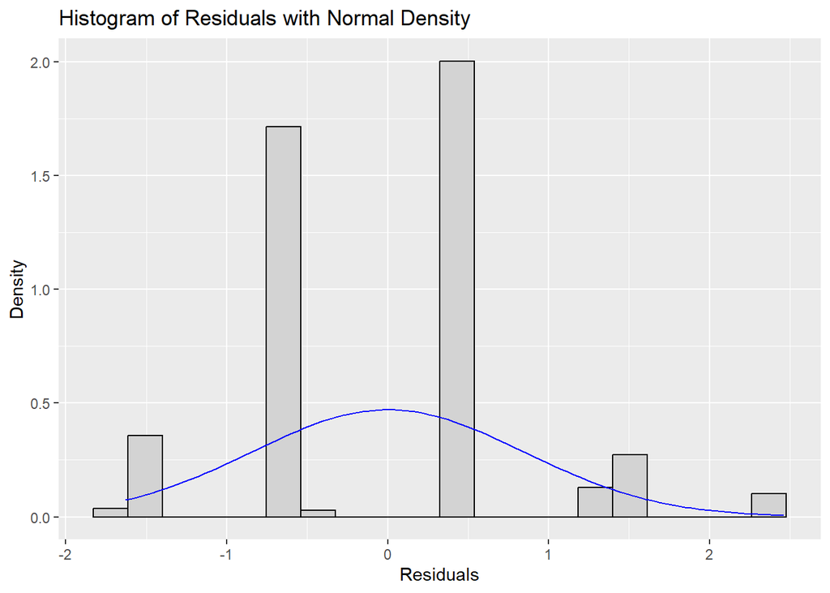

```r
# Histogram of residuals with a normal density line
# A good model should have residuals that resemble a normal distribution

ggplot(data.frame(Residuals = residuals), aes(x = Residuals)) +
  geom_histogram(aes(y = ..density..), bins = 20, color = "black", fill = "lightgray") +
  stat_function(fun = dnorm, args = list(mean = mean(residuals), sd = sd(residuals)), color = "blue") +
  labs(title = "Histogram of Residuals with Normal Density", x = "Residuals", y = "Density")
```

## Conclusion: Main Takeaways

The analysis of the relationship between age and perceptions of crime safety (`CRIMESAFE`) provides some nuanced insights. Both the regression analysis and the Pearson correlation coefficient indicate a weak negative relationship between age and perceived crime insecurity, suggesting that as individuals age, they tend to feel slightly more secure (or less insecure). However, this relationship is not strong or strictly linear, as evidenced by the low R-squared value and marginal p-value in the regression output.

Interestingly, when we examine the data using a chi-square test of independence on categorical age cohorts, we observe a statistically significant association between age groups and crime safety perception. The chi-square test result, with a chi-square statistic of 45.659, 16 degrees of freedom, and a p-value of 0.0001099, indicates that the association between age cohort and crime safety perception is unlikely to be due to chance. This significance suggests that age groups do indeed differ in their perceptions of crime safety, though not in a simple linear pattern.

In summary, while linear regression analysis does not strongly support a linear relationship between age and crime safety perception, the chi-square test reveals a significant association between age groups and different levels of perceived insecurity. This association is complex and non-linear, as illustrated by the varying mean values across age cohorts in the plot. This suggests that age impacts perceptions of crime safety in nuanced ways that a simple linear model cannot fully capture: younger adults tend to feel more insecure, while older adults generally feel more secure.